# Human Activity Recognition (HAR) using a Random Forest Classifier

PML Student

Wednesday, January 21, 2015

# 1 Introduction

In recent years, with the use of consumer products such as *Jawbone Up*, *Nike FuelBand*, and *Fitbit*, it has become easier for entusiasts to collect large quantities of personal movement data. However, data on the *quality of the movements*, how well excersices are performed, is rarely quantified.

In this paper, we will use data collected from accelerometers on the belt, forearm, arm, and dumbell of six participants to predict the manner in which they performed barbell lift exercises (the **classe** variable in the data set). Participants in the experiment were asked to perform barbell lifts correctly and incorrectly in five different ways. More information is available from http://groupware.les.inf.puc-rio.br/har (see the section on the Weight Lifting Exercise Dataset).

After the model was developed, it was used to predict on 20 activities. The feature data used to predict the 20 activities was obtained from https://d396qusza40orc.cloudfront.net/predmachlearn/pml-testing.csv

# 2 Approach

## 2.1 Data

The data used for this paper is the Human Activity Recognition (HAR) referenced in the “Wearable Computing: Accelerometers’ Data Classification of Body Postures and Movements” paper by Ugulino, W.; Cardador, D.; Vega, K.; Velloso, E.; Milidiu, R.; Fuks, H.

The data was obtained from https://d396qusza40orc.cloudfront.net/predmachlearn/pml-training.csv and loaded in R to build our classification model.

```r
#setwd("./Project")
pml.dat <- read.csv("./Data/pml-training.csv")
```

## 2.2 Data Cleaning and Preparation

We removed identifiers for the experiment record, which did not add value to the classification problem.

```r
non.movement.columns <- c(1:7) ; names(pml.dat[non.movement.columns])
```

```
## [1] "X"                    "user_name"            "raw_timestamp_part_1"
## [4] "raw_timestamp_part_2" "cvtd_timestamp"       "new_window"
## [7] "num_window"
```

In addition, features that are missing more than 19000 out of the 19622 measurements (as blanks or NA’s) were removed, as imputing them would add no value to building our model.

```r
# GET LIST OF COLUMNS IN pml-training.csv EXCLUDING COLUMNS WITH >19000 NA VALUES AND SPACES
trim <- function (x) gsub("^\\s+|\\s+$", "", x)
pml.dat.summary <- data.frame(summary(pml.dat))  # function to trim leading & trailing blanks
exclude.columns <- rbind( subset(pml.dat.summary ,
                                 grepl("^:19([0-9]{3,})",trim(pml.dat.summary$Freq) ) ,
                                 select="Var2") ,
                          subset(pml.dat.summary ,
                                 grepl("^NA's   :19([0-9]{3,})",trim(pml.dat.summary$Freq) ) ,
                                 select="Var2") )
include.field <- names(pml.dat[,-c(exclude.columns$Var2 , non.movement.columns)])
```

After eliminating these columns we ended up with a data frame of 19622 samples and the following 53 columns.

```
##  [1] "roll_belt"            "pitch_belt"           "yaw_belt"
##  [4] "total_accel_belt"     "gyros_belt_x"         "gyros_belt_y"
##  [7] "gyros_belt_z"         "accel_belt_x"         "accel_belt_y"
## [10] "accel_belt_z"         "magnet_belt_x"        "magnet_belt_y"
## [13] "magnet_belt_z"        "roll_arm"             "pitch_arm"
## [16] "yaw_arm"              "total_accel_arm"      "gyros_arm_x"
## [19] "gyros_arm_y"          "gyros_arm_z"          "accel_arm_x"
## [22] "accel_arm_y"          "accel_arm_z"          "magnet_arm_x"
## [25] "magnet_arm_y"         "magnet_arm_z"         "roll_dumbbell"
## [28] "pitch_dumbbell"       "yaw_dumbbell"         "total_accel_dumbbell"
## [31] "gyros_dumbbell_x"     "gyros_dumbbell_y"     "gyros_dumbbell_z"
## [34] "accel_dumbbell_x"     "accel_dumbbell_y"     "accel_dumbbell_z"
## [37] "magnet_dumbbell_x"    "magnet_dumbbell_y"    "magnet_dumbbell_z"
## [40] "roll_forearm"         "pitch_forearm"        "yaw_forearm"
## [43] "total_accel_forearm"  "gyros_forearm_x"      "gyros_forearm_y"
## [46] "gyros_forearm_z"      "accel_forearm_x"      "accel_forearm_y"
## [49] "accel_forearm_z"      "magnet_forearm_x"     "magnet_forearm_y"
## [52] "magnet_forearm_z"     "classe"
```

## 2.3 Partitioning the HAR Data

We partitioned the data into **training** and **testing** data frames.

```r
# PARTITION DATA INTO TRAINING and TESTING ####
set.seed(77777)
i.train.test <- createDataPartition(pml.dat$classe , p=0.8 , list=FALSE)
training <- pml.dat[i.train.test,include.field]
testing <- pml.dat[-i.train.test,include.field]
```

The **training** data frame was used to build our model. It consists of 15699 rows.  
The **testing** data frame was used to estimate our out of sample error. It consists of 3923 rows.

## 2.4 Building the Model

To predict the correct activity, we explored the use of different classification models with built in feature selections. We then examined their accuracy against our out of sample data frame, **testing**.

- rt - 99.92% Accuracy with mtry=2 and 98.87% with mtry=27 for the OOS Error
- knn - 95% Accuracy with k=5 for the OOS Error
- rpart - 50.38% Accuracy for the OOS Error
- AdaBoost - 28.26% Accuracy for the OOS Error

Out of the tested models the Random Forest (**rf**) model returned the highest accuracy.

## 2.5 Model Training

The **rf** model was trained using a 10-fold cross-validation, which was repeated 10 times. The **train** function in the **caret** R package was used to control our cross-validation strategy. The **trControl** parameter of the **train** function provided us with finer control over our model training.

These sample was then split into 10 sub-samples, or 10-fold, by the value of **number** parameter. A model was fit on 9 of the 10 samples. This process was repeated for each of the 10 folds and then aggregated by the **train** function.

This process was repeated 10 times as controled by the **repeat** parameter value of **10**.

```r
# FIT Random Forest ####
my.grid <- expand.grid(mtry = c(2,27,52) )

# http://topepo.github.io/caret/training.html#control
fitControl <- trainControl(method = "repeatedcv",
                           number = 10,
                           repeats = 10,
                           verboseIter = T,
                           p = 0.7
)

# Traning Random Forest
set.seed(77777)
rf.mod <- train(x=training[,-dim(training)[2]] , y=as.factor(training$classe) ,
                linout=FALSE ,
                method="rf" ,
                tuneGrid = my.grid ,
                trControl = fitControl
)
```

In addition, the random forest model was tried for trees built on different number of columns controled by the *mtry* parameter of the **rf** model. The **train** used the calculated **Accuracy** to select the best model, for our model, an **mtry** value of **2**.

[output not shown]

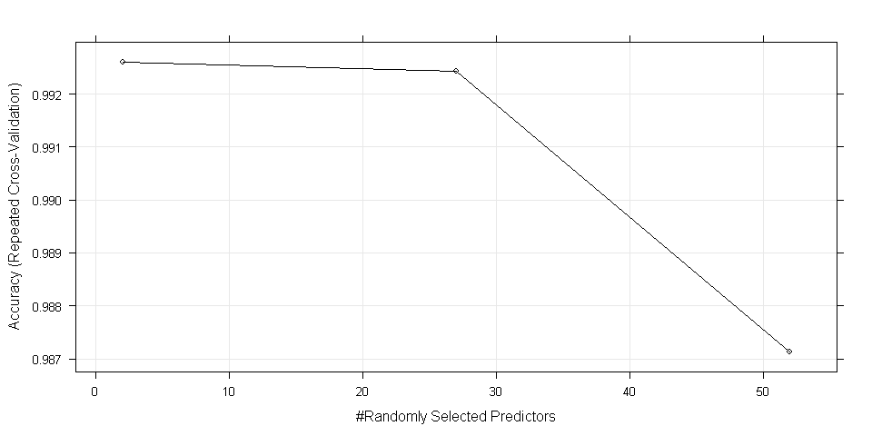

Due to the amount of time it took to train the model, we also saved the trained **rf** model. We are able to load it later using the **load()** R command.

```r
# SAVE rf.mod TRAINING OBJECT
save( rf.mod , file="rf_mod_training")
```

## 2.6 Final Trained Model Accuracy

The final trained **rf** model confusion matrix is summarized below.

```r
# TRAINING SAMPLE CONFUSION MATRIX FOR TRAINING ERROR
(confusionMatrix( predict(rf.mod, training) , training$classe ))
```

```
## Confusion Matrix and Statistics
##
##           Reference
## Prediction    A    B    C    D    E
##          A 4463    9    0    0    0
##          B    1 3028   10    0    0
##          C    0    1 2728   18    0
##          D    0    0    0 2552    1
##          E    0    0    0    3 2885
##
## Overall Statistics
##
##                Accuracy : 0.9973
##                  95% CI : (0.9963, 0.998)
##     No Information Rate : 0.2843
##     P-Value [Acc > NIR] : < 2.2e-16
##
##                   Kappa : 0.9965
##  Mcnemar's Test P-Value : NA
##
## Statistics by Class:
##
##                      Class: A Class: B Class: C Class: D Class: E
## Sensitivity            0.9998   0.9967   0.9963   0.9918   0.9997
## Specificity            0.9992   0.9991   0.9985   0.9999   0.9998
## Pos Pred Value         0.9980   0.9964   0.9931   0.9996   0.9990
## Neg Pred Value         0.9999   0.9992   0.9992   0.9984   0.9999
## Prevalence             0.2843   0.1935   0.1744   0.1639   0.1838
## Detection Rate         0.2843   0.1929   0.1738   0.1626   0.1838
## Detection Prevalence   0.2849   0.1936   0.1750   0.1626   0.1840
## Balanced Accuracy      0.9995   0.9979   0.9974   0.9959   0.9997
```

## 2.7 Estimated Out Of Sample Error

To get an estimate of the Out Of Sample Error, we used the **testing** data frame partitioned earlier. We use our trained model to predict the correct class and compare it to the actual class from the **classe** column.

```r
# TEST SAMPLE CONFUSION MATRIX (ESTIMATE OF OOS ERROR)
(confusionMatrix( predict(rf.mod, testing) , testing$classe ))
```

```
## Confusion Matrix and Statistics
##
##           Reference
## Prediction    A    B    C    D    E
##          A 1116    2    0    0    0
##          B    0  757    0    0    0
##          C    0    0  684    0    0
##          D    0    0    0  642    0
##          E    0    0    0    1  721
##
## Overall Statistics
##
##                Accuracy : 0.9992
##                  95% CI : (0.9978, 0.9998)
##     No Information Rate : 0.2845
##     P-Value [Acc > NIR] : < 2.2e-16
##
##                   Kappa : 0.999
##  Mcnemar's Test P-Value : NA
##
## Statistics by Class:
##
##                      Class: A Class: B Class: C Class: D Class: E
## Sensitivity            1.0000   0.9974   1.0000   0.9984   1.0000
## Specificity            0.9993   1.0000   1.0000   1.0000   0.9997
## Pos Pred Value         0.9982   1.0000   1.0000   1.0000   0.9986
## Neg Pred Value         1.0000   0.9994   1.0000   0.9997   1.0000
## Prevalence             0.2845   0.1935   0.1744   0.1639   0.1838
## Detection Rate         0.2845   0.1930   0.1744   0.1637   0.1838
## Detection Prevalence   0.2850   0.1930   0.1744   0.1637   0.1840
## Balanced Accuracy      0.9996   0.9987   1.0000   0.9992   0.9998
```

For this model, **Accuracy** of the test data was higher than that of the training data.

Below we classified 10 random samples from the **testing** data using our trained model and compared the **predicted classe** values to their **actual classe** values.

```r
# PREDICT 10 RANDOM SAMPLES OF THE TESTING DATA
random.samples <- sample(rownames(testing),size=10,replace=FALSE) # Sample Observations
data.frame( pml.dat[random.samples , c(2,6,7)],
            Actual=pml.dat[random.samples,"classe"] ,
            Predicted=predict( rf.mod , testing[random.samples,include.field[1:52]] )
            )
```

```
##       user_name new_window num_window Actual Predicted
## 17092   charles         no        155      E         E
## 3526     jeremy         no        417      A         A
## 17067   charles         no        154      E         E
## 3118   carlitos         no        343      A         A
## 14314  carlitos        yes        394      D         D
## 16563  carlitos         no         39      E         E
## 1118     adelmo         no        194      A         A
## 14402    jeremy         no        480      D         D
## 16077    adelmo         no          4      E         E
## 12275   charles         no        728      C         C
```

## 2.8 Variable Importance

As outlined earlier, the model also has built-in feature selection. Below we summarize each feature’s importance in our final model.

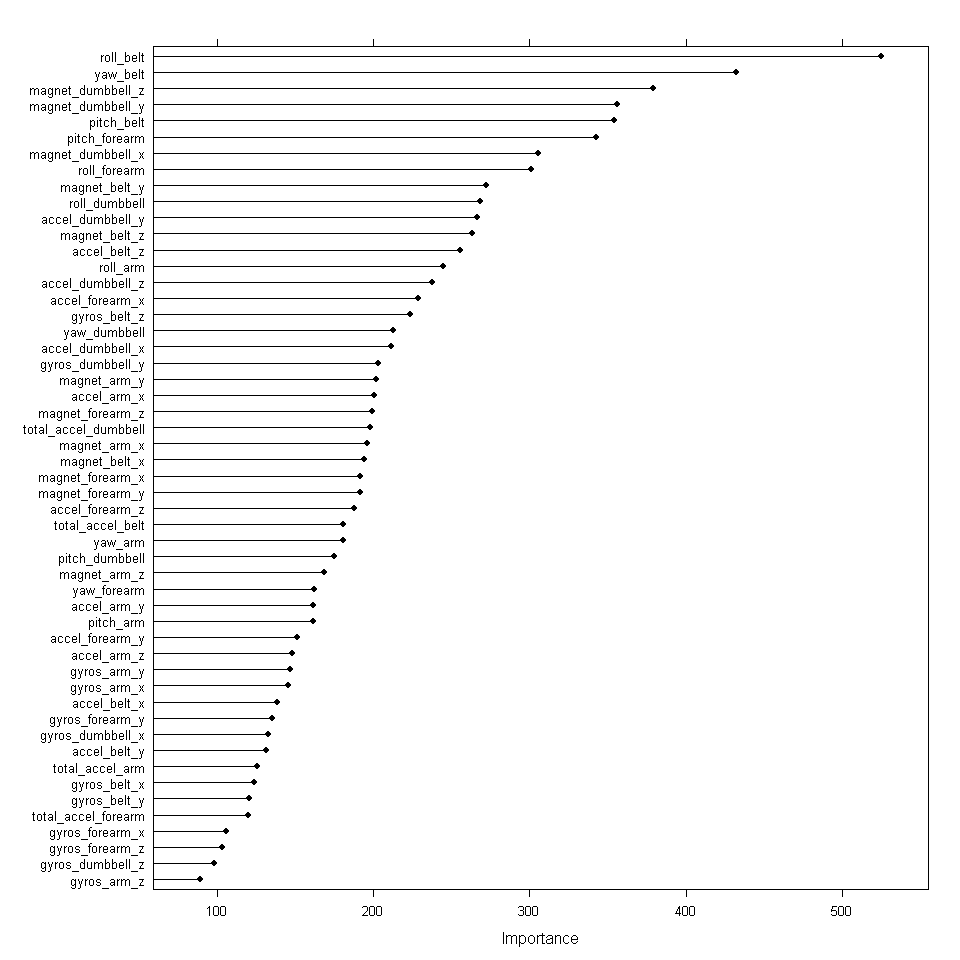

```r
plot(varImp(rf.mod, scale = FALSE))
```

```r
library(AppliedPredictiveModeling)
transparentTheme(trans = .4)

random.samples <- sample(rownames(training),size=50,replace=FALSE)

important <- data.frame(
    feature=rownames(varImp(rf.mod, scale = FALSE)$importance) ,
    varImp(rf.mod, scale = FALSE)$importance
    )
head(important <- important[order(important$Overall , decreasing=T),] , 8)
```

```
##                             feature  Overall
## roll_belt                 roll_belt 525.0369
## yaw_belt                   yaw_belt 432.2016
## magnet_dumbbell_z magnet_dumbbell_z 379.2310
## magnet_dumbbell_y magnet_dumbbell_y 356.2896
## pitch_belt               pitch_belt 353.9717
## pitch_forearm         pitch_forearm 342.5646
## magnet_dumbbell_x magnet_dumbbell_x 305.8481
## roll_forearm           roll_forearm 300.8780
```

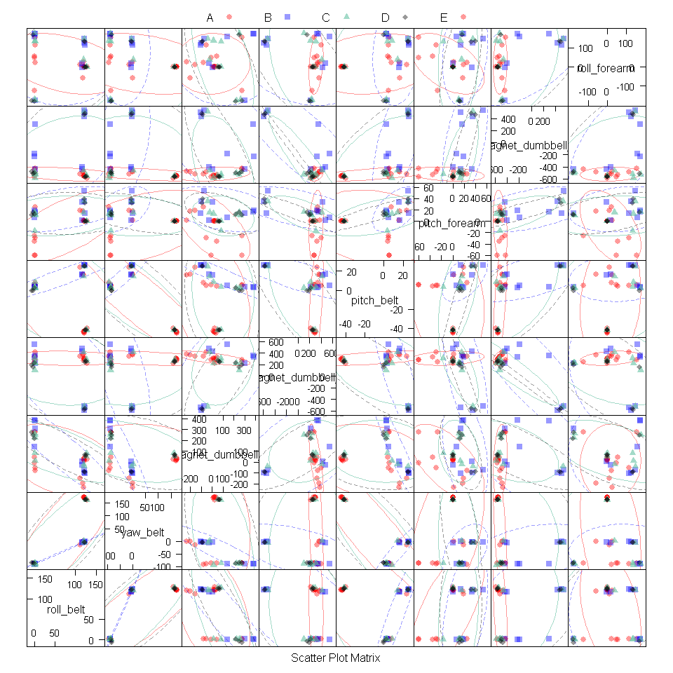

```r
featurePlot(x=training[random.samples,as.vector(important[1:8,"feature"])] ,
            y=training[random.samples,"classe"] ,
            plot = "ellipse" ,
            auto.key = list(columns = 5)
            )
```

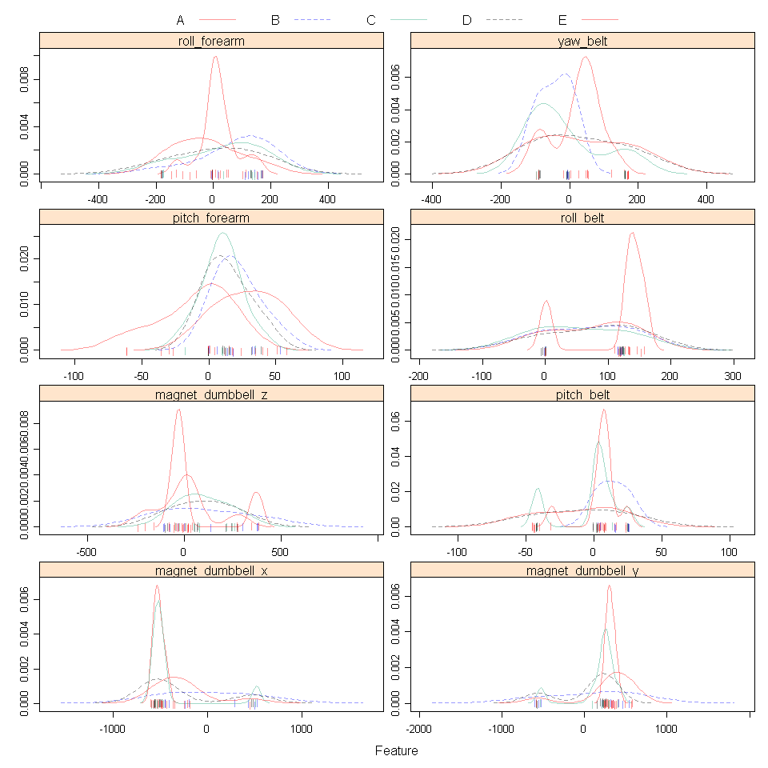

```r
featurePlot(x=training[random.samples,as.vector(important[1:8,"feature"])] ,
            y=training[random.samples,"classe"] ,
            plot = "density" ,
            scales=list(x=list(relation="free"),
                        y=list(relation="free")),
            adjust=1.5,
            pch="|",
            layout=c(2,4),
            auto.key = list(columns = 5)
            )
```

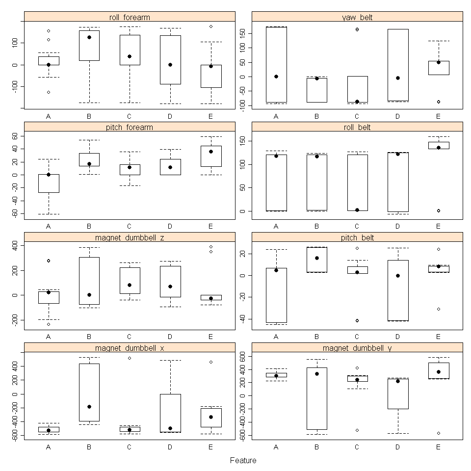

```r
featurePlot(x=training[random.samples,as.vector(important[1:8,"feature"])] ,
            y=training[random.samples,"classe"] ,
            plot = "box" ,
            scales=list(x=list(relation="free"),
                        y=list(relation="free")),
            adjust=1.5,
            layout=c(2,4),
            auto.key = list(columns = 5)
            )
```